# Who the Count Missed

The census grades itself, state by state, and mostly returns a blank

Democracy’s Data

Last updated September 13, 2026 at 10:53a EDT

The census sets out to count every person in the country, once, at the right address. The rest of American politics then treats the result as exact: House seats, electoral votes and federal money are all handed out on the published numbers. So the claim behind the whole arrangement is that the count comes close enough. Is that true — how close does the census actually come, and who gets missed?

The Census Bureau answers that question about itself. After each census it runs a second survey whose only job is to grade the first, and it publishes the grade. This brief reads the 2020 grade in both directions: **who** the count missed, by age, sex, race and housing, and **where**, state by state. The two answers do not look alike, and the reason they differ is the thing worth carrying out of here.

## The test

The data is the Bureau’s evaluation of the 2020 census: the **Post-Enumeration Survey**, a second and much smaller count taken after the main one (an enumeration is a head count), published in two reports in 2022 — the [national estimates by demographic group](https://www2.census.gov/programs-surveys/decennial/coverage-measurement/pes/national-census-coverage-estimates-by-demographic-characteristics.pdf) in March and the [estimates by state](https://www2.census.gov/programs-surveys/decennial/coverage-measurement/pes/census-coverage-estimates-for-people-in-the-united-states-by-state-and-census-operations.pdf) in May. After the count, interviewers went back to a sample of about 10,000 census blocks, the smallest areas the Bureau publishes and often a single city block, and counted the people living there from scratch, without reference to what the census had found. The two lists were then matched person by person, across roughly 114,000 completed household interviews. Someone the survey found and the census did not is evidence of an omission; someone the census has twice is evidence of a duplicate. The gap between the estimated true population and the published count is **net coverage error**.

This is the right source because it is the only one there is. No independent register of American residents exists to check a census against, so the only instrument that can grade a count is another count, done carefully on a sample and matched name by name. What an enumeration is, and why nothing else can stand in for one, is the subject of the census chapter.

Three properties of the design decide everything below. **It is a sample**, so every number it produces is an estimate with a margin printed beside it, a stated figure for how far off the estimate could be. **It is a net measure**: a state where 40,000 people were missed and 40,000 counted twice comes out at zero, the same as a state where nothing went wrong. **And it covers the household population only.** People in dormitories, prisons, nursing homes and shelters are evaluated separately, so about 8,249,281 residents appear in no figure in this brief.

## The data

Five tables come out of this chapter with enough rows and columns to build a question of your own on. Here they are before any of it is used, with what each holds and how big it is; the rest of this section is about where the numbers came from and which columns repay attention. Sizes are rows by columns, read off the files. (Three more files are Figure 1’s map geometry, linked where that figure is; two more are records of how this chapter itself was built, linked below the checks.)

| Table | What it holds | Size |
| --- | --- | --- |
| `states.csv` | One row per state and DC: the certified count, the 2020 estimate and its margin, the Bureau’s own mark, the people the rate implies, the 2010 comparison and the self-response share. | 51 × 13 |
| `race.csv` | National coverage error by race and Hispanic origin, 2020 beside 2010. | 12 × 7 |
| `age.csv` | National coverage error by age group. | 9 × 5 |
| `age_sex.csv` | Coverage error by age and sex, both censuses. | 48 × 6 |
| `tenure.csv` | Coverage error for owners and for renters, both censuses. | 12 × 5 |

Both reports exist only as PDF. The Bureau publishes no spreadsheet or data file of these numbers, so every table here was transcribed from the reports’ own printed tables, at the two addresses above. Two features of those printed tables matter to anyone reading them. The minus signs are set as dashes, so an undercount does not look like a negative number until you know that. And “On Reservation” is indented beneath the American Indian or Alaska Native row, which is the only thing recording that it is a subdivision of that row rather than a category beside it.

The state table, `states.csv`, holds one row per state plus the District of Columbia: the certified `census_count`, the 2020 estimate `est_2020`, the margin `se_2020`, and the people the rate implies, `implied_people`. The column `bureau_states_it` records the Bureau’s own mark. In the report it is an asterisk meaning the agency will say which way that state’s count went; `direction` says which way. Each row also carries `self_response`, the share of housing units that answered on their own, taken from the Bureau’s response-rate file, listed in the sources.

The demographic tables (`race.csv`, `age.csv`, `age_sex.csv` and `tenure.csv`) carry the same three columns for national groups: the estimate, the margin, and the mark. One more published breakdown, not really a dataset of its own but the Bureau’s official account of what the count is made of, is `components.csv`: the national count broken into correct enumerations, duplicates and the rest.

Two more files are not data about the census at all – they are how this chapter checked its own work, kept so a reader can verify the checking rather than take it on faith: `facts.csv`, the individual numbers quoted in the text above, and `checks.csv`, the arithmetic verified against the reports before anything was drawn:

| Check | Value |
| --- | --- |
| state rows parsed out of Appendix Table 3 | 50 states and DC, out of 52 printed rows |
| state names in alphabetical order, matched to FIPS | 51 matched, 0 unmatched |
| the Bureau’s marks, checked against the numbers printed beside them | 50 of 51 track; Delaware is the exception |
| national estimate, identical in all four PES tables | -0.24% in all four |
| self-response rate, national, against the published figure | 67.0%, as published |
| internet self-response below overall, every state | 51 of 51 |
| map rings joined to a coverage estimate | 128 of 128 rings |
| median published margin, one state against one national group | 1.43 against 0.48 percentage points |

> **Before you read on, commit to a number.** The Bureau publishes a net coverage error for each of the 50 states and the District of Columbia — 51 numbers — and marks the rows where it is willing to say which way the count went. **On how many of the 51 do you think it puts that mark?** Write the number down before you look at the map.

## What it says about democracy

Start with the national line. The survey reads it as an undercount of 0.24%, about 777,546 people, with a margin of 0.25 beside it and **no mark**. The Bureau publishes the number and declines to say the country was undercounted. That combination, a number plus a refusal to stand behind it, is the shape of most of what follows.

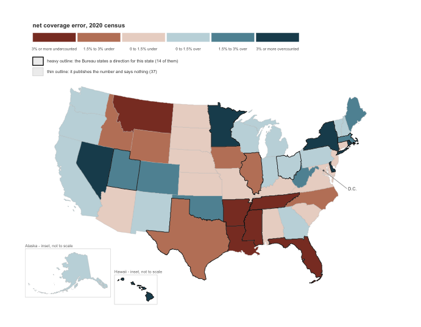

**Figure 1. Net coverage error in the 2020 census, by state.** A map, because the question is where; two channels, because the source has two columns. Fill is the number the Bureau published — rust where the count is estimated to have missed people, slate where it holds more people than live there. The outline is the Bureau’s mark: only the heavy-outlined states are ones it will characterise. Hover any state for its estimate, its margin, and what the rate implies in people.

The map’s own geometry – not data to analyze, but there if you want to redraw it – is `map_states.csv` (one row per drawn piece, its bin and polygon points), `map_bins.csv` (the color bins and their labels) and `map_insets.csv` (the frames Alaska and Hawaii are drawn in).

The answer to the question you wrote down is 14. **The Bureau calls 6 states undercounted**: Arkansas, Florida, Illinois, Mississippi, Tennessee, and Texas. **It calls 8 overcounted**: Delaware, Hawaii, Massachusetts, Minnesota, New York, Ohio, Rhode Island, and Utah. On the remaining 37, it publishes a number and says nothing about which way the count went. The state report card is mostly blank.

The blanks are not modesty about small numbers. The median margin printed beside a state, the middle value with half the states above it and half below, is 1.43 points; the median estimate is 0.10. When a publisher hedges a number by more than the number is worth, it is telling you how far the table can be pushed. District of Columbia posts +4.59%, the largest number on the map, and carries no mark at all. Put five rows side by side and the logic shows:

| State | Estimate | Margin printed beside it | The Bureau says |
| --- | --- | --- | --- |
| Illinois | -1.97% | 0.89 | undercounted |
| Louisiana | -3.73% | 2.36 | nothing |
| Ohio | +1.49% | 0.67 | overcounted |
| District of Columbia | +4.59% | 4.93 | nothing |
| Montana | -4.39% | 3.70 | nothing |

Illinois’s number says the count missed 1.97% of its people, Louisiana’s nearly twice that. **The Bureau calls Illinois undercounted and says nothing about Louisiana.** The difference is the middle column: the survey saw Illinois closely enough to describe it and did not see Louisiana closely enough to describe it. The mark tracks the margin, not the size of the number. So the rule for using this table needs no arithmetic: read across the row, because a number quoted without its margin and its mark is not the Bureau’s claim.

Cut the same survey by demographic group instead of by state and it stops being blank.

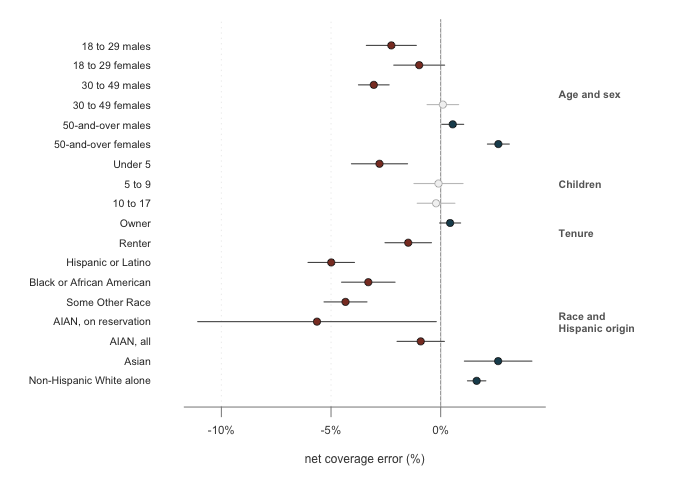

**Figure 2. Every national demographic estimate in this brief, with the margin the Bureau prints beside it drawn to scale.** Filled circles are rows the Bureau characterises; hollow circles are rows where it says nothing. The bars are short, a median of 0.48 points here against 1.43 for a state, because a national group is measured with the whole sample while a state gets only its own slice.

This is the **differential undercount**, the census’s habit of missing some groups at higher rates than others, and four rows of it are worth saying out loud. **Children under five are undercounted by 2.79%**, one of the largest rates in the survey and one of the most persistent across censuses; children aged 5 to 9 come in at -0.10%, unmarked. **Men aged 30 to 49 are undercounted 3.05%** while women the same age come in near zero, a gap that age alone would average away. **Renters are undercounted 1.48% and owners overcounted 0.43%**, a pair that has appeared in each of the last four censuses. And the race rows repeat what the decennial chapter reported from the press release: Black residents 3.30% undercounted, Hispanic residents 4.99%, non-Hispanic White residents 1.64% *over*counted.

One indented pair in the race table deserves its own sentence. American Indian and Alaska Native residents living on reservations were undercounted 5.64%, the worst rate in the survey, while those living elsewhere came in at -0.86%. The Bureau’s headline rate for the group, 0.91%, is the average of the two — smaller than the rate in the places where the problem is worst.

An overcount is not a harmless error in the other direction. It is duplicates and people counted in the wrong place: women over 50, at 2.63%, and homeowners generally. It inflates a group’s weight just as surely as an omission deflates another’s.

Why does this matter for democracy rather than just for statistics? Because the count is the currency of representation, and an undercount is not neutral. The 2020 apportionment handed out one House seat per 761,169 people. Texas’s rate implies about 558,695 people missing, 73.4% of a seat; Florida’s implies 759,673, 99.8% of a seat; New York’s overcount implies 651,485 in excess. The last seat in 2020 turned on a margin of a few dozen people, the subject of the apportionment chapter.

Federal money moves on the same numbers. And Figure 2 says who pays: the people the count misses are disproportionately renters, young children, and Black, Hispanic and Native residents. The people counted twice are disproportionately owners and the settled old. Representation and money drift, quietly, from the first list toward the second.

The grade cannot fix any of it. Congress lets the Bureau sample in its work “except for the determination of population for purposes of apportionment”,[^1] and in 1999 the Supreme Court read that to bar a sampled apportionment count.[^2] After 1990 the Secretary of Commerce declined to adjust the census using that decade’s version of this survey, and the Court upheld the refusal in *Wisconsin v. City of New York* (1996).[^3] So the Post-Enumeration Survey exists to describe the problem, not to repair it: an agency’s careful measurement of how wrong its own flagship product is, published in full, with no mechanism attached.

## What this brief cannot tell you

**Net coverage error is not accuracy.** About 5.8% of people were omissions, and about 3.4% of the published count were whole-person imputations, records the Bureau filled in by guessing a person from the household around them. Both dwarf the 0.24% net they produce. A state at zero is not a state where nothing happened; it is a state where the errors came out even.

**No state-by-race table exists.** The Bureau does not publish coverage by state crossed with race, age or tenure, so you cannot get from Figure 2 to a claim about who was missed in Georgia. Anyone who applies the national rates to one state’s counts is illustrating, not estimating.

**A blank is not a clean bill of health.** On 37 states the survey did not see enough to say which way the count went. That gets reported as “this state was fine” constantly, and the correct reading is “we do not know”.

**The 2010 comparison does not work at the state level.** The state table labels the 2020 margin a standard error, the usual statistical measure of how far a sample estimate is likely to sit from the truth, and the 2010 one a wider quantity that also covers a bias the newer method removed. Subtracting the columns hands you a change for every state, and the Bureau marked none of them.

**The household population is the whole frame.** The 8,249,281 people in group quarters (the dormitories, prisons, nursing homes and shelters above) and in Remote Alaska are outside every figure here, and Puerto Rico was evaluated on a separate design and published separately.

## What you should have learned

- The census grades itself: the 2020 survey reads the national count as 0.24% short, about 777,546 people, and the Bureau still declines to state a direction for the country.
- The state report card is mostly blank: the Bureau marks 14 of 51 states, and the mark tracks the margin beside a number, not the size of the number.
- The undercount is differential: children under five at 2.79%, renters at 1.48%, residents on reservations at 5.64%, while owners and older women are counted twice often enough to show as overcounts.
- An undercount moves representation and money away from the people missed: Florida’s implied gap is 99.8% of a House seat, and the law forbids using this survey to correct any of it.
- A net figure near zero is a balance of errors, not an absence of them.

## Extensions

None of these is answered above, and every one can be answered by sorting or grouping in a spreadsheet.

- `states.csv` carries `bureau_states_it` beside `census_count`. Count the TRUE rows, then add up the population living in them. What share of the country’s people got an answer the Bureau was prepared to stand behind?
- `states.csv` also has `self_response` and `internet_response`. Sort by `self_response` and set it against `est_2020`. Do the states that answered on their own get counted better, or is answering by mail a different thing from being counted?
- `race.csv` puts `est_2020` beside `est_2010` for each group. Which groups moved, and in which direction? Then ask whether that is the count improving or the measure changing.
- `components.csv` breaks the count into correct enumerations and everything else in its `percent` column. Work out what share of the published count is not a correct enumeration, and decide whether that number surprises you.

Two stretch ideas, beyond the spreadsheet. Download the Bureau’s 2010 coverage report, whose national demographic tables use a comparable design, and build the same picture as Figure 2 to ask whether the differential undercount is narrowing. Or take the six undercounted and eight overcounted states and re-run the 2020 apportionment with their counts adjusted by `est_2020`, to see whether any seat actually changes hands.

## Sources

**Data**

- U.S. Census Bureau. *Census Coverage Estimates for People in the United States by State and Census Operations*, 2020 Post-Enumeration Survey Estimation Report, May 2022 release. Appendix Table 3 is the state table used throughout: census count, 2020 estimate, the margin beside it, and the Bureau’s asterisks, which its footnote calls estimates “significantly different from zero” — the marks the outlines in Figure 1 draw. https://www2.census.gov/programs-surveys/decennial/coverage-measurement/pes/census-coverage-estimates-for-people-in-the-united-states-by-state-and-census-operations.pdf
- U.S. Census Bureau. *National Census Coverage Estimates for People in the United States by Demographic Characteristics*, 2020 Post-Enumeration Survey Estimation Report, March 2022 release. Table 4 is race and Hispanic origin, Table 6 tenure across four censuses, Table 10 age crossed with sex, Table 11 age alone. https://www2.census.gov/programs-surveys/decennial/coverage-measurement/pes/national-census-coverage-estimates-by-demographic-characteristics.pdf
- U.S. Census Bureau. *2020 Census self-response rates*, the file behind the Bureau’s response-rate map, `decennialrr2020.csv`. The rates in `states.csv` are the column `CRRALL` at the final posting, 2021-01-29; the similarly named `CMAX` is the maximum over the geographies inside a state and belongs to some tract, not to the state. https://www2.census.gov/programs-surveys/decennial/2020/data/tracking-response-rates/self-response-rates-map/
- State outlines are the Census cartographic-boundary state file, projected and simplified for the migration chapter and reused here unchanged.

**Statute and cases**

- Census Act, 13 U.S.C. § 195 (sampling, “except for the determination of population for purposes of apportionment”). https://www.law.cornell.edu/uscode/text/13/195
- *Wisconsin v. City of New York*, 517 U.S. 1 (1996) — the Secretary’s refusal to adjust the 1990 count using that decade’s post-enumeration survey, upheld. https://www.law.cornell.edu/supremecourt/text/517/1
- *Department of Commerce v. U.S. House of Representatives*, 525 U.S. 316 (1999) — sampling barred for the apportionment count. https://www.law.cornell.edu/supremecourt/text/525/316

**The data itself**

The five tables worth building your own question on are described in The data at the top of this brief. They are plain CSV, they open in a spreadsheet, and they are yours to take further: `states.csv`, `race.csv`, `age.csv`, `age_sex.csv`, `tenure.csv`. Figure 1’s map geometry is linked where the figure is. `components.csv`, the Bureau’s own published breakdown of the count, and `facts.csv` and `checks.csv`, records of how this chapter was built rather than data about the census, are linked where each is introduced.

Rebuild this data yourself, with an AI assistant

```
I want to rebuild a public dataset from its original sources, without
any starting files. Please do the following and show your work.

THE SOURCES. U.S. Census Bureau, three of them, all open, no key.
1. "Census Coverage Estimates for People in the United States by
   State and Census Operations", Post-Enumeration Survey report
   PES20-G-02, May 2022:
   https://www2.census.gov/programs-surveys/decennial/coverage-measurement/pes/census-coverage-estimates-for-people-in-the-united-states-by-state-and-census-operations.pdf
   Appendix Table 3 is the state table: for each state, the census
   count, the estimated net coverage error, its standard error, and
   an asterisk wherever the Bureau stands behind a direction.
2. "National Census Coverage Estimates for People in the United
   States by Demographic Characteristics", report PES20-G-01, March
   2022:
   https://www2.census.gov/programs-surveys/decennial/coverage-measurement/pes/national-census-coverage-estimates-by-demographic-characteristics.pdf
   National estimates by race and Hispanic origin, by age and sex,
   and by whether the home is owned or rented.
3. The 2020 Census self-response rates, one CSV of about 7.6 MB:
   https://www2.census.gov/programs-surveys/decennial/2020/data/tracking-response-rates/self-response-rates-map/decennialrr2020.csv
   One row per geography, from the nation down to tracts.

HOW TO READ THEM. The two reports exist only as PDF -- no CSV, no
API, no spreadsheet anywhere on the Bureau's site. Extract the text
with a layout-preserving tool (poppler's pdftotext with its -layout
flag works) and parse the tables out of the text. Two hazards. In the
PDFs, negative numbers are printed with an en dash rather than a
hyphen-minus; convert it or every undercount refuses to be a number.
In the rates CSV, the column you want is CRRALL, the cumulative
self-response rate. The columns CMAX and CINTMAX read like final
rates and are nothing of the sort: they are the maximum over the
geographies inside each row's area. Alabama's CRRALL is 63.6; its
CMAX is 77.8, and the second number is some tract in Alabama, not
Alabama.

WHAT TO BUILD.
1. The state table: 50 states and DC, each with its net coverage
   estimate, its standard error, and whether the Bureau marked it --
   and a count of the marked ones, split undercount against
   overcount.
2. The national estimates by demographic group, from the second
   report, with their standard errors.
3. Self-response by state from CRRALL, plus the national rate.

CHECK YOUR WORK. The copies this book used were downloaded in August
2026. If your rebuild matches them, you should find:
- a national net coverage estimate of -0.24%, printed identically in
  all four tables of the demographic report
- the Bureau marks 14 of the 51 state estimates: six undercounts and
  eight overcounts
- state standard errors run from 0.65 to 4.93 percentage points
- the rates file has 123,248 rows, and the national self-response
  rate is 67.0%
Everything here is final: the PES reports will not be revised, the
rates file stopped moving in 2021, and the next survey of this kind
follows the 2030 census.
```

[^1]: Census Act, 13 U.S.C. § 195: https://www.law.cornell.edu/uscode/text/13/195.
[^2]: *Department of Commerce v. U.S. House of Representatives*, 525 U.S. 316 (1999): https://www.law.cornell.edu/supremecourt/text/525/316.
[^3]: 517 U.S. 1 (1996): https://www.law.cornell.edu/supremecourt/text/517/1.